# Разработка модели с целью прогнозирования заказов такси

# Описание проекта

Компания «Яндекс Go» собрала исторические данные о заказах такси в аэропортах. Чтобы привлекать больше водителей в период пиковой нагрузки, нужно спрогнозировать количество заказов такси на следующий час.

Построение модели для прогнозирования количества заказов такси в аэропорту может помочь компании «Яндекс Go» эффективно привлекать водителей в период пиковой нагрузки. Правильное прогнозирование позволит улучшить качество обслуживания клиентов и сделать работу водителей более рентабельной.

Требование заказчика - значение метрики *RMSE* на тестовой выборке должно быть не больше 48.

# План работы

**Шаг 1. Подготовка**

Необходимо загрузить данные и выполнить их ресемплирование по одному часу.

**Шаг 2. Анализ**

Необходимо проанализировать данные.

**Шаг 3. Обучение**

Необходимо обучить разные модели с различными гиперпараметрами. Сделать тестовую выборку размером 10% от исходных данных.

**Шаг4. Тестирование**

Требуется проверить данные на тестовой выборке и сделать выводы.

# Описание данных

Данные лежат в файле `taxi.csv`. Количество заказов находится в столбце `num_orders` (от англ. *number of orders*, «число заказов»).

## Подготовка

На данном этапе необходимо загрузить данные и выполнить их ресемплирование по одному часу.

### Импортируем необходимые библиотеки

```python
!pip install -q -U scikit-learn

import pandas as pd
import numpy as np
import seaborn as sns
import matplotlib.pyplot as plt
import scipy.stats as st
import sklearn

RANDOM_STATE = 12345

import warnings
warnings.filterwarnings('ignore')

from sklearn.model_selection import RandomizedSearchCV
from sklearn.model_selection import train_test_split, GridSearchCV, TimeSeriesSplit

from sklearn.pipeline import Pipeline, make_pipeline
from sklearn.preprocessing import OneHotEncoder, OrdinalEncoder, StandardScaler
from sklearn.compose import make_column_transformer, make_column_selector
from sklearn.metrics import mean_squared_error, make_scorer

from sklearn.model_selection import GridSearchCV, TimeSeriesSplit

from sklearn.linear_model import LinearRegression
from sklearn.tree import DecisionTreeRegressor
from sklearn.ensemble import RandomForestRegressor
from lightgbm import LGBMRegressor
from catboost import CatBoostRegressor
from sklearn.dummy import DummyRegressor


from joblib import dump, load
from statsmodels.tsa.seasonal import seasonal_decompose
```

### Загрузим данные

```python
try:
    df = pd.read_csv('/datasets/taxi.csv')
except:
    df = pd.read_csv('https://code.s3.yandex.net/datasets/taxi.csv', encoding='utf8')
```

```python
df.head(3)
```

|  | datetime | num_orders |
| --- | --- | --- |
| 0 | 2018-03-01 00:00:00 | 9 |
| 1 | 2018-03-01 00:10:00 | 14 |
| 2 | 2018-03-01 00:20:00 | 28 |

```python
df.info()
```

```
<class 'pandas.core.frame.DataFrame'>
RangeIndex: 26496 entries, 0 to 26495
Data columns (total 2 columns):
 #   Column      Non-Null Count  Dtype
---  ------      --------------  -----
 0   datetime    26496 non-null  object
 1   num_orders  26496 non-null  int64
dtypes: int64(1), object(1)
memory usage: 414.1+ KB
```

```python
df.index.min(), df.index.max()
```

```
(0, 26495)
```

### Выполним ресемплирование по одному часу

```python
df['datetime'] = df['datetime'].astype('datetime64')
```

```python
df.index.is_monotonic
```

```
True
```

```python
df = df.set_index('datetime')
```

```python
df = df.resample('1H').sum()
```

### Выводы по подготовке данных:

- Изменили тип данных у столбца с датой с `object` на `datetime64`;
- Проверили в хронологическом ли порядке расположены даты и время с помомощью атрибута `is_monotonic`;
- Выполнили ресемплирование по одному часу.

## Анализ

На данном этапе необходимо проанализировать данные.

### Постром график временного ряда

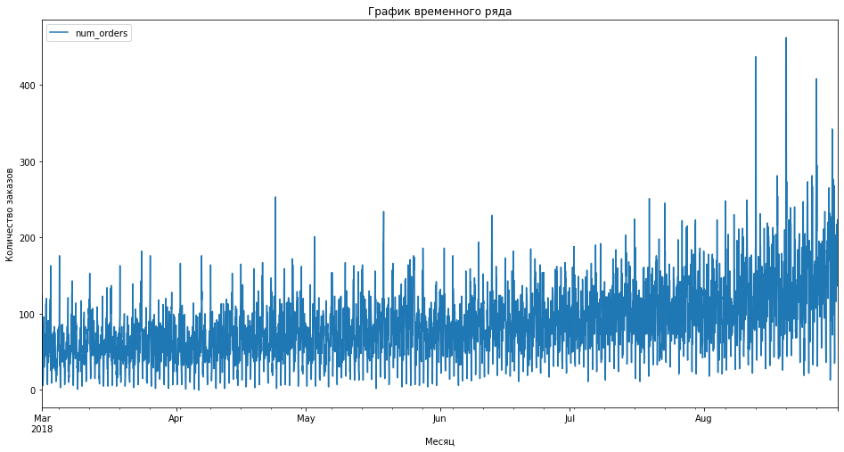

```python
df.plot(title = 'График временного ряда',
        figsize=(16, 8))
plt.xlabel('Месяц')
plt.ylabel('Количество заказов');
```

### Построим распределение заказов по часам в течение суток

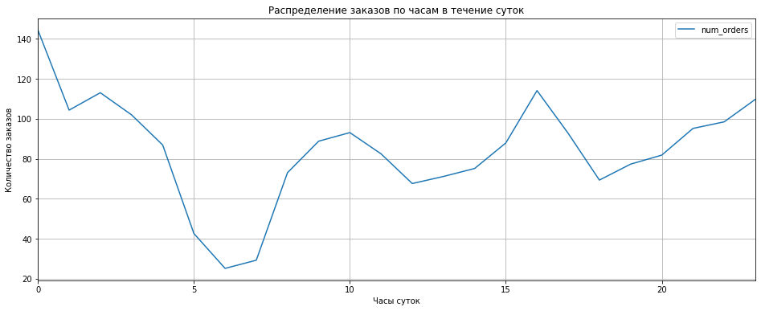

```python
df.groupby(df.index.hour).mean().plot(title = 'Распределение заказов по часам в течение суток',
                                      xlabel='Часы суток',
                                      ylabel='Количество заказов',
                                      grid=True,
                                      xlim=(0, 23),
                                      figsize=(16, 6));
```

### Построим распределение заказов по дням в течение недели

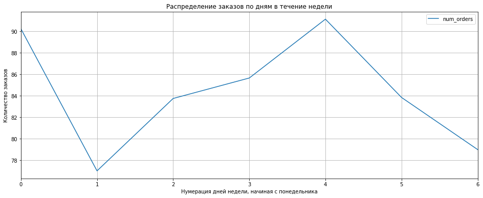

```python
df.groupby(df.index.weekday).mean().plot(title = 'Распределение заказов по дням в течение недели',
                                      xlabel='Нумерация дней недели, начиная с понедельника',
                                      ylabel='Количество заказов',
                                      grid=True,
                                      xlim=(0, 6),
                                      figsize=(16, 6));
```

### Построим распределение заказов по дням в течение месяца

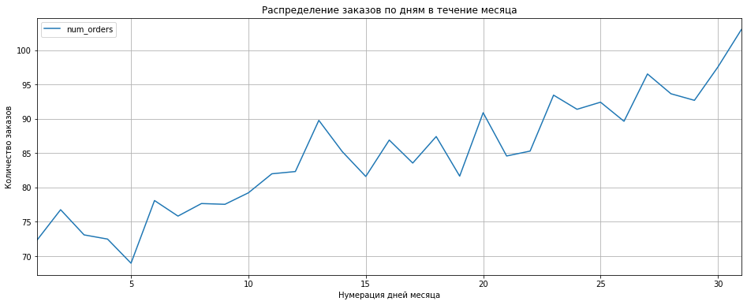

```python
df.groupby(df.index.day).mean().plot(title = 'Распределение заказов по дням в течение месяца',
                                      xlabel='Нумерация дней месяца',
                                      ylabel='Количество заказов',
                                      grid=True,
                                      xlim=(1, 31),
                                      figsize=(16, 6));
```